# **Panorama da inflação**

# IPCA

O Indíce de Preços ao Consumidor Amplo (IPCA) variou 1.32% em março, valor superior ao mesmo período do ano anterior quando apresentou uma taxa de 0.92%. Com esse resultado o indíce acumula no ano uma variação positiva de 3.83%, e em 12 meses uma variação positiva de 8.13%.

|  | 03/2014 | 02/2015 | 03/2015 |
| --- | --- | --- | --- |
| Variação mensal | 0.92% | 1.22% | 1.32% |
| Variação acumulada no ano | 2.18% | 2.48% | 3.83% |
| Variação acumulada em 12 meses | 6.15% | 7.7% | 8.13% |

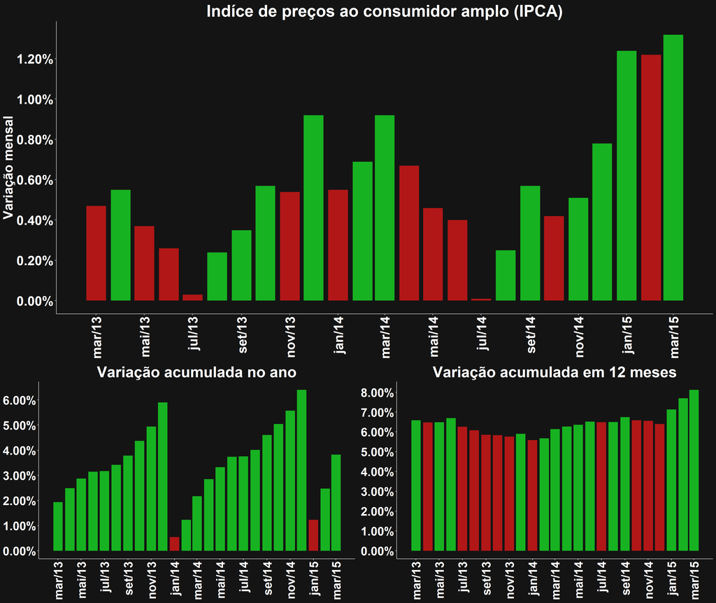

|  | Variação mensal | Variação acumulada no ano | Peso mensal |
| --- | --- | --- | --- |
| Alimentação e bebidas | 1.17% | 3.5% | 24.89% |
| Habitação | 5.29% | 9.15% | 14.9% |
| Artigos de residência | 0.35% | 0.94% | 4.41% |
| Vestuário | 0.59% | -0.7% | 6.25% |
| Transportes | 0.46% | 4.55% | 18.82% |
| Saúde e cuidados pessoais | 0.69% | 1.62% | 11.12% |
| Despesas pessoais | 0.36% | 2.92% | 10.76% |
| Educação | 0.75% | 7% | 4.76% |
| Comunicação | -1.16% | -1.03% | 4.1% |

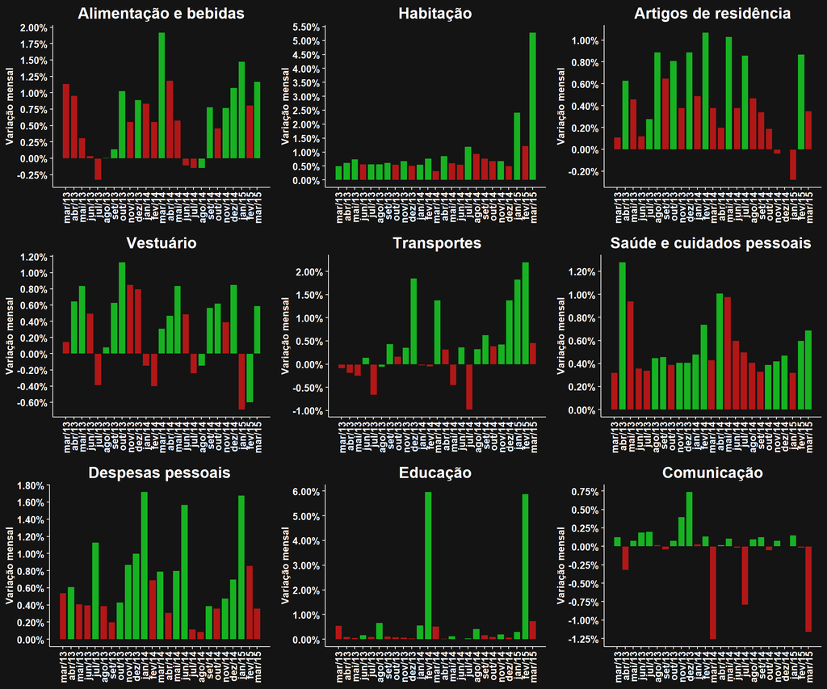

A nível de sub-itens os que mais influenciaram positivamente no resultado em relação ao seu peso foram Energia elétrica residencial (22.08%%) e Refeição (1.03%%), e negativamente Passagem aérea (-15.45%%) e Telefone fixo (-4.13%%).

|  | Variação mensal | Variação acumulada no ano | Peso mensal |
| --- | --- | --- | --- |
| Energia elétrica residencial | 22.08% | 36.33% | 3.21% |
| Lanche | 1.87% | 4.6% | 2% |
| Gasolina | 1.26% | 9.8% | 3.99% |
| Refeição | 1.03% | 2.5% | 5.15% |

|  | Variação mensal | Variação acumulada no ano | Peso mensal |
| --- | --- | --- | --- |
| Excursão | -1.98% | 10.7% | 0.4% |
| Passagem aérea | -15.45% | -38.32% | 0.48% |
| Batata-inglesa | -2.4% | 28.27% | 0.29% |
| Telefone fixo | -4.13% | -4.73% | 1.14% |

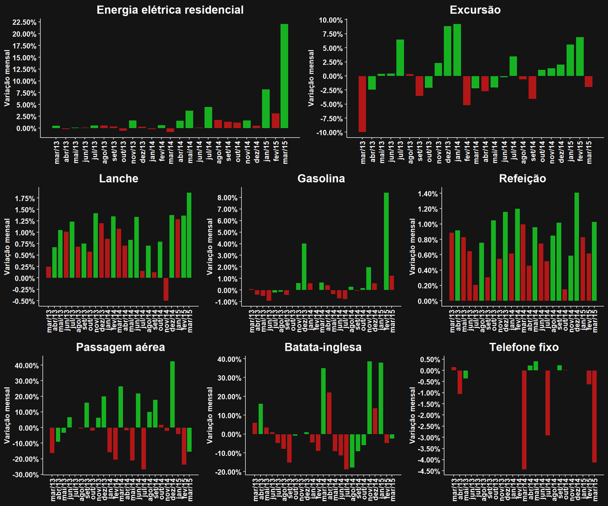